# Machine Learning Engineer Nanodegree

## Project: Creating Customer Segments

## Getting Started

In this project, you will analyze a dataset containing data on various customers' annual spending amounts (reported in *monetary units*) of diverse product categories for internal structure. One goal of this project is to best describe the variation in the different types of customers that a wholesale distributor interacts with. Doing so would equip the distributor with insight into how to best structure their delivery service to meet the needs of each customer.

The dataset for this project can be found on the [UCI Machine Learning Repository](https://archive.ics.uci.edu/ml/datasets/Wholesale+customers). For the purposes of this project, the features `'Channel'` and `'Region'` will be excluded in the analysis — with focus instead on the six product categories recorded for customers.

Run the code block below to load the wholesale customers dataset, along with a few of the necessary Python libraries required for this project. You will know the dataset loaded successfully if the size of the dataset is reported.

```python
# Import libraries necessary for this project
import numpy as np
import pandas as pd
from IPython.display import display # Allows the use of display() for DataFrames

# Import supplementary visualizations code visuals.py
import visuals as vs

# Pretty display for notebooks
import matplotlib.pyplot as plt
import seaborn as sns
%matplotlib inline

# Load the wholesale customers dataset
try:
    data = pd.read_csv("customers.csv")
    data.drop(['Region', 'Channel'], axis = 1, inplace = True)
    print "Wholesale customers dataset has {} samples with {} features each.".format(*data.shape)
except:
    print "Dataset could not be loaded. Is the dataset missing?"
```

```
Wholesale customers dataset has 440 samples with 6 features each.
```

## Data Exploration

In this section, you will begin exploring the data through visualizations and code to understand how each feature is related to the others. You will observe a statistical description of the dataset, consider the relevance of each feature, and select a few sample data points from the dataset which you will track through the course of this project.

Run the code block below to observe a statistical description of the dataset. Note that the dataset is composed of six important product categories: **'Fresh'**, **'Milk'**, **'Grocery'**, **'Frozen'**, **'Detergents_Paper'**, and **'Delicatessen'**. Consider what each category represents in terms of products you could purchase.

```python
# Display a description of the dataset
display(data.describe())
```

|  | Fresh | Milk | Grocery | Frozen | Detergents_Paper | Delicatessen |
| --- | --- | --- | --- | --- | --- | --- |
| count | 440.000000 | 440.000000 | 440.000000 | 440.000000 | 440.000000 | 440.000000 |
| mean | 12000.297727 | 5796.265909 | 7951.277273 | 3071.931818 | 2881.493182 | 1524.870455 |
| std | 12647.328865 | 7380.377175 | 9503.162829 | 4854.673333 | 4767.854448 | 2820.105937 |
| min | 3.000000 | 55.000000 | 3.000000 | 25.000000 | 3.000000 | 3.000000 |
| 25% | 3127.750000 | 1533.000000 | 2153.000000 | 742.250000 | 256.750000 | 408.250000 |
| 50% | 8504.000000 | 3627.000000 | 4755.500000 | 1526.000000 | 816.500000 | 965.500000 |
| 75% | 16933.750000 | 7190.250000 | 10655.750000 | 3554.250000 | 3922.000000 | 1820.250000 |
| max | 112151.000000 | 73498.000000 | 92780.000000 | 60869.000000 | 40827.000000 | 47943.000000 |

### Implementation: Selecting Samples

To get a better understanding of the customers and how their data will transform through the analysis, it would be best to select a few sample data points and explore them in more detail. In the code block below, add **three** indices of your choice to the `indices` list which will represent the customers to track. It is suggested to try different sets of samples until you obtain customers that vary significantly from one another.

```python
# TODO: Select three indices of your choice you wish to sample from the dataset
indices = [0, 10, 100]

# Create a DataFrame of the chosen samples
samples = pd.DataFrame(data.loc[indices], columns = data.keys()).reset_index(drop = True)
print "Chosen samples of wholesale customers dataset:"
display(samples)
```

```
Chosen samples of wholesale customers dataset:
```

|  | Fresh | Milk | Grocery | Frozen | Detergents_Paper | Delicatessen |
| --- | --- | --- | --- | --- | --- | --- |
| 0 | 12669 | 9656 | 7561 | 214 | 2674 | 1338 |
| 1 | 3366 | 5403 | 12974 | 4400 | 5977 | 1744 |
| 2 | 11594 | 7779 | 12144 | 3252 | 8035 | 3029 |

### Question 1

Consider the total purchase cost of each product category and the statistical description of the dataset above for your sample customers.

- What kind of establishment (customer) could each of the three samples you've chosen represent?

Knowing this, how do your samples compare? Does that help in driving your insight into what kind of establishments they might be?

**Answer:** The first customer buys mostly fresh products and milk, with some grocery. This could be a cafe, since they buy a lot of milk. The second buys a lot of grocery, but not much fresh, meaning it may be a grocery store without produce. Finally, the third customer buys a lot of grocery and fresh, meaning it could be a grocery store with both categories.

Update: I make the following observations using the table and heatmap below:

- In the heatmap, very light and very dark colors represent extreme standardized values. Orange is slightly positive, purple is near-mean. Each row is a sample and each column is a variable. We can see that the first sample customer buys slightly more of `Milk` and not much at all of `Frozen`. The second sample buys very little `Fresh` and a moderate amount each of `Grocery`, `Frozen`, and `Detergents_Paper`. Finally, the third sample buys a moderate amount of `Milk`, `Grocery`, and `Delicatessen`, and a *lot* of `Detergents_Paper`. That being said, since none of these samples is very remarkable in any of the categories (only sample three has a standardized score beyond one standard deviation, for `Detergents_Paper`), each of these points is relatively average.

```python
standardized_samples = ((samples - data.mean())/data.std()).round(2)
standardized_samples
```

|  | Fresh | Milk | Grocery | Frozen | Detergents_Paper | Delicatessen |
| --- | --- | --- | --- | --- | --- | --- |
| 0 | 0.05 | 0.52 | -0.04 | -0.59 | -0.04 | -0.07 |
| 1 | -0.68 | -0.05 | 0.53 | 0.27 | 0.65 | 0.08 |
| 2 | -0.03 | 0.27 | 0.44 | 0.04 | 1.08 | 0.53 |

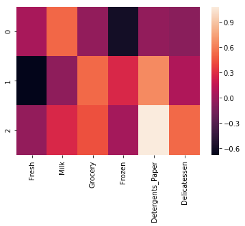

```python
sns.heatmap(standardized_samples);
```

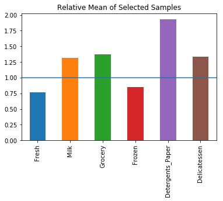

```python
ax = (samples.mean() / data.mean()).plot(kind='bar')
ax.set_title('Relative Mean of Selected Samples');
ax.axhline(y=1);
```

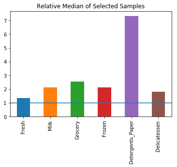

```python
ax = (samples.median() / data.median()).plot(kind='bar')
ax.set_title('Relative Median of Selected Samples');
ax.axhline(y=1);
```

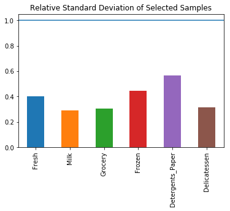

```python
ax = (samples.std() / data.std()).plot(kind='bar')
ax.set_title('Relative Standard Deviation of Selected Samples');
ax.axhline(y=1);
```

### Implementation: Feature Relevance

One interesting thought to consider is if one (or more) of the six product categories is actually relevant for understanding customer purchasing. That is to say, is it possible to determine whether customers purchasing some amount of one category of products will necessarily purchase some proportional amount of another category of products? We can make this determination quite easily by training a supervised regression learner on a subset of the data with one feature removed, and then score how well that model can predict the removed feature.

In the code block below, you will need to implement the following:

- Assign `new_data` a copy of the data by removing a feature of your choice using the `DataFrame.drop` function.
- Use `sklearn.cross_validation.train_test_split` to split the dataset into training and testing sets.
  - Use the removed feature as your target label. Set a `test_size` of `0.25` and set a `random_state`.
- Import a decision tree regressor, set a `random_state`, and fit the learner to the training data.
- Report the prediction score of the testing set using the regressor's `score` function.

```python
from sklearn.cross_validation import train_test_split
from sklearn.tree import DecisionTreeRegressor

# TODO: Make a copy of the DataFrame, using the 'drop' function to drop the given feature
new_data = data.drop('Fresh', axis=1)

# TODO: Split the data into training and testing sets(0.25) using the given feature as the target
# Set a random state.
X_train, X_test, y_train, y_test = train_test_split(new_data, data['Fresh'], test_size=0.25, random_state=69*42)

# TODO: Create a decision tree regressor and fit it to the training set
regressor = DecisionTreeRegressor(random_state=42)
regressor.fit(X_train, y_train)

# TODO: Report the score of the prediction using the testing set
score = regressor.score(X_test, y_test)
score
```

```
-0.16331384087337431
```